# Assignment5

```python
# Select categorical columns
categorical_cols = df.select_dtypes(include=['object']).columns

# Apply OrdinalEncoder to categorical columns
encoder = OrdinalEncoder()
df[categorical_cols] = encoder.fit_transform(df[categorical_cols].astype(str))
print("Categorical data encoded successfully!")
```

```
Categorical data encoded successfully!
```

```python
# Assuming 'fit' is the label column for this context
labels = df['fit']

# Add the label column to the features
X = df.copy()  # Make a copy of the original DataFrame to include 'fit'
X['fit_label'] = labels  # Add label column as a feature
```

```python
# Handle missing data
imputer = SimpleImputer(strategy='mean')
X_imputed = imputer.fit_transform(X)
print("Missing data handled successfully!")
```

```
Missing data handled successfully!
```

```python
# Perform PCA
pca_model = sm.PCA(X_imputed, ncomp=2, method='nipals', missing='fill-em')
print("PCA performed successfully!")

# Extract principal components
pc = pca_model.factors
df_pca = pd.DataFrame(pc, columns=['PC1', 'PC2'])
print("Principal components extracted successfully!")
print(df_pca.head())
print(df_pca.describe())
```

```
PCA performed successfully!
Principal components extracted successfully!
        PC1       PC2
0 -0.001249 -0.008568
1  0.000307 -0.009417
2  0.001072 -0.010326
3  0.002085  0.000362
4  0.002660 -0.007818
                PC1           PC2
count  8.279000e+04  8.279000e+04
mean  -5.105564e-18 -2.923404e-18
std    3.475471e-03  3.475471e-03
min   -1.149186e-02 -1.217409e-02
25%   -2.466187e-03 -2.098148e-03
50%   -4.594149e-04  3.313620e-04
75%    2.080866e-03  2.544884e-03
max    1.973394e-02  1.433679e-02
```

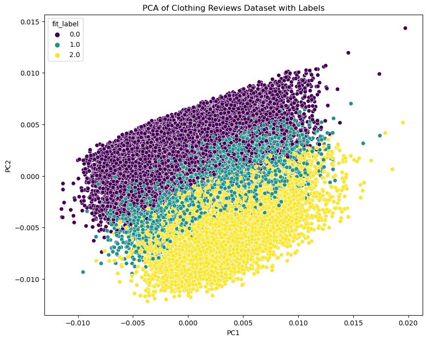

```python
# Add labels to the PCA DataFrame for visualization
df_pca['fit_label'] = labels

# Plot using seaborn
plt.figure(figsize=(10, 8))
sns.scatterplot(x='PC1', y='PC2', hue='fit_label', palette='viridis', data=df_pca)
plt.title('PCA of Clothing Reviews Dataset with Labels')
plt.show()
```

```python
# Extract the text reviews and ensure all values are strings
reviews = df['review_text'].dropna().astype(str)
print(f"Number of reviews: {len(reviews)}")
```

```
Number of reviews: 82790
```

```python
n_features = 1000

# Use tf (raw term count) features for LDA.
print("Extracting tf features for LDA...")
tf_vectorizer = CountVectorizer(
    max_df=0.95, min_df=2, max_features=n_features, stop_words="english"
)
tf = tf_vectorizer.fit_transform(reviews)
print("done extracting tf features.")
```

```
Extracting tf features for LDA...
done extracting tf features.
```

```python
n_components = 10
n_top_words = 20

print("Fitting LDA model...")
lda = LatentDirichletAllocation(
    n_components=n_components,
    max_iter=5,
    learning_method="online",
    learning_offset=50.0,
    random_state=0,
)
lda.fit(tf)
print("LDA model fitted.")
```

```
Fitting LDA model...
LDA model fitted.
```

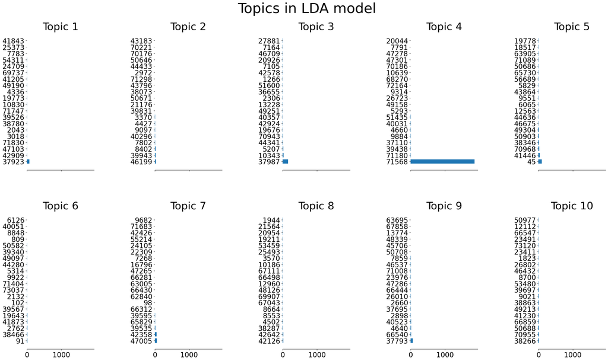

```python
def plot_top_words(model, feature_names, n_top_words, title):
    fig, axes = plt.subplots(2, 5, figsize=(30, 15), sharex=True)
    axes = axes.flatten()
    for topic_idx, topic in enumerate(model.components_):
        top_features_ind = topic.argsort()[:-n_top_words - 1:-1]  # Corrected to get top words
        top_features = [feature_names[i] for i in top_features_ind]
        weights = topic[top_features_ind]

        ax = axes[topic_idx]
        ax.barh(top_features, weights, height=0.7)
        ax.set_title(f"Topic {topic_idx + 1}", fontdict={"fontsize": 30})
        ax.tick_params(axis="both", which="major", labelsize=20)
        for i in "top right left".split():
            ax.spines[i].set_visible(False)
        fig.suptitle(title, fontsize=40)

    plt.subplots_adjust(top=0.90, bottom=0.05, wspace=0.90, hspace=0.3)
    plt.show()

tf_feature_names = tf_vectorizer.get_feature_names_out()
plot_top_words(lda, tf_feature_names, n_top_words, "Topics in LDA model")
```

# t-SNE and Manifold Learning

```python
# Remove data points with missing data
no_missing_data = df.dropna()
print(f"Number of data points after removing missing data: {len(no_missing_data)}")
```

```
Number of data points after removing missing data: 908
```

```python
# Select numerical features for t-SNE
numerical_features = no_missing_data.select_dtypes(include=['float64', 'int64']).columns
X = no_missing_data[numerical_features].drop(columns=['size'])  # Exclude 'size' from features

# Check if there are any non-numeric columns left
print("Selected numerical features:")
print(X.head())

# Apply t-SNE
perplexity = 30  # You can vary this parameter
tsne = TSNE(n_components=2, perplexity=perplexity, random_state=0)
X_embedded = tsne.fit_transform(X)
print("t-SNE embedding completed.")
```

[output not shown]

```
t-SNE DataFrame head:
   Dimension 1  Dimension 2  size
0    -4.830271   -21.708233    12
1    31.089058   -16.046213     8
2    22.558678   -19.661026     8
3    19.185335   -21.465174    12
4   -22.099428   -22.142494    32
```

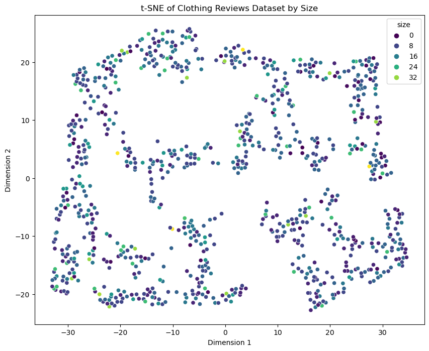

```python
# Create a DataFrame with the t-SNE results
tsne_df = pd.DataFrame(X_embedded, columns=['Dimension 1', 'Dimension 2'])
tsne_df['size'] = no_missing_data['size'].values  # Ensure correct alignment of the 'size' column

# Check the first few rows of the t-SNE DataFrame
print("t-SNE DataFrame head:")
print(tsne_df.head())

# Plot using seaborn
plt.figure(figsize=(10, 8))
sns.scatterplot(x='Dimension 1', y='Dimension 2', hue='size', palette='viridis', data=tsne_df)
plt.title('t-SNE of Clothing Reviews Dataset by Size')
plt.show()
```

# Written Questions

1.How many principal components do you think are necessary for the cat faces dataset? Which measurement of the number of features, using the eigenvectors or cross-validation, do you think would be likely to give better results for answering this question? Connect your answer to what you know about supervised learning.

For the cat faces dataset, around 20-30 principal components might be necessary to capture most of the variance. Using eigenvectors to measure the number of features tends to give better results for this question as it directly relates to the variance explained by each component. This is similar to selecting features in supervised learning, where capturing the most informative features can lead to better model performance.

2.Compare the results you obtained from the cat faces to the human faces in the original demo. What could be done to the cat faces dataset to get results that look more like the results using human faces

The cat faces dataset results were likely less clear compared to the human faces due to less variation and possibly lower quality or resolution of images. To improve the results, the cat faces dataset could be augmented with more varied images, higher resolution, and better alignment preprocessing to ensure consistency in features.

3.In the review data, you plotted the data by label along with the principal components. You also looked at the top topics extracted from the text of the reviews. Which of these two do you think is a more meaningful representation of the data?

4.Which data worked better in the Module 4 Assignment, when you used the clothing data for supervised learning? Does this have any relationship to the unsupervised analysis you have done of these data?

5.Did embedding the data using t-Distributed Stochastic Neighbor Embedding (t-SNE) give any additional information about the review data? Do you see more structure in the data with this nonlinear model than the one using PCA?